# **UF-6 Actividad Evaluable: Mapas de calor y boxplots**

## Ruth Maya López / A01707467

## Leonardo Isaías Guevara Pioquinto / A01275327

## Valeria Medina Martinez / A01275070

```python
# Importamos las librerias
import numpy as np
import pandas as pd
import seaborn as sns
from turtle import color
import matplotlib.pyplot as plt
import scipy.special as special
from scipy.optimize import curve_fit
from sklearn.metrics import r2_score
from sklearn.linear_model import LinearRegression
```

```python
# Lectura del Excel y las columnas correspondientes
antiguedad = pd.read_excel('Calor.xlsx', sheet_name="antiguedad")
productos = pd.read_excel('Calor.xlsx', sheet_name="productos")
clientesfact = pd.read_excel('Calor.xlsx', sheet_name="clientesfact")
clientesnot = pd.read_excel('Calor.xlsx', sheet_name="clientesnot")
clientesdev = pd.read_excel('Calor.xlsx', sheet_name="clientesdev")
clientes = pd.read_excel('Calor.xlsx', sheet_name="clientes")
gastos2020 = pd.read_excel('Calor.xlsx', sheet_name="gastos2020")
gastos2021 = pd.read_excel('Calor.xlsx', sheet_name="gastos2021")
gastos2022 = pd.read_excel('Calor.xlsx', sheet_name="gastos2022")
gastos2023 = pd.read_excel('Calor.xlsx', sheet_name="gastos2023")
```

# **ANÁLISIS POR DATAFRAME**

**CORRELACIÓN EN MAPA DE CALOR**

Primeramente es importante definir que la **correlación** es una medida estadística que expresa hasta qué punto dos variables están relacionadas linealmente.

Por otro lado, el **mapa de calor** es una tabla que utiliza una escala de colores fríos y cálidos para representar los valores de las casillas.

Considerando lo anterior, es como se determinó evaluar las variables de cada uno de los dataframes, obteniendo las correlaciones que existen entre cada columna de los mismos y mostrar los resultados en un mapa de calor para visualmente analizar la relación de las variables.

**ANTIGUEDAD**

- Existe sólo una columna con valores numéricos, por lo tanto, consideramos que no sera de mucha utilidad aplicar los métodos de regresión para esta hoja de cálculo.

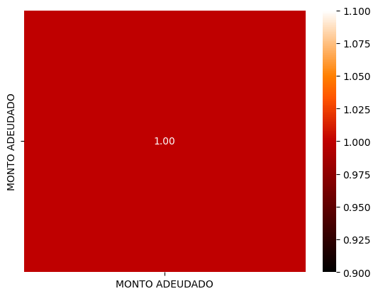

```python
#Mostramos el mapa de calor de los coeficientes de correlación para las variables numericas de cada dataframe.
Heat_Map= sns.heatmap(abs(antiguedad.corr()), cmap = 'gist_heat', annot=True, fmt=".2f")
Heat_Map
```

**PRODUCTOS**

- Existen varias columnas numéricas en las cuales se observan porcentajes de correlación diferentes.
- La mayor correlación se observa con las variables "Costo unitario calculado" y "Costo total calculado". mostrando un 94%.
- Con un 2%, la correlación menor encontrada se presenta con las variables "Costo unitario calculado" y "Cantidad", presentada en dos dimensiones diferentes del mapa de calor.

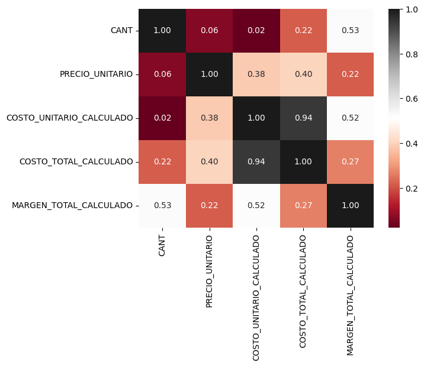

```python
#Mostramos el mapa de calor de los coeficientes de correlación para las variables numericas de cada dataframe.
Heat_Map= sns.heatmap(abs(productos.corr()), cmap = 'RdGy', annot=True, fmt=".2f")
Heat_Map
```

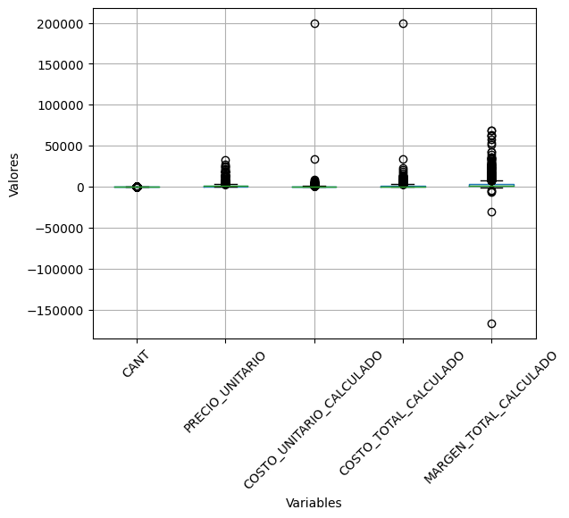

```python
#Mostrar la dispersión de las variables del dataframe
boxplot = productos.boxplot(column=['CANT','PRECIO_UNITARIO', 'COSTO_UNITARIO_CALCULADO', 'COSTO_TOTAL_CALCULADO', 'MARGEN_TOTAL_CALCULADO'])
boxplot.set_xticklabels(boxplot.get_xticklabels(), rotation=45)
plt.xlabel('Variables')
plt.ylabel('Valores')
plt.show()
```

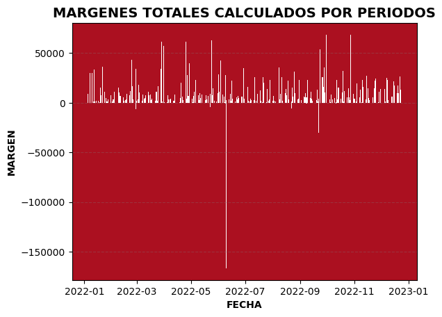

```python
Barras=plt.bar(productos['FECHA_DOC'],productos['MARGEN_TOTAL_CALCULADO'],color='white')
ax = plt.gca()
ax.set_facecolor('#ab1020')
plt.title('MARGENES TOTALES CALCULADOS POR PERIODOS',  fontdict = {'fontsize':14, 'fontweight':'bold'})
plt.ylabel('MARGEN', fontdict = {'fontsize':10, 'fontweight':'bold'})
plt.xlabel('FECHA', fontdict = {'fontsize':10, 'fontweight':'bold'})
plt.grid(axis = 'y', color = 'gray', linestyle = 'dashed', alpha = 0.3)
plt.show()
```

**CLIENTES FACTURACIÓN**

- Existen varias columnas numéricas en las cuales se observan porcentajes de correlación diferentes.
- La mayor correlación se observa con las variables "Cantidad total" y "Descuento total". mostrando un 24%, siendo así un porcentaje muy reducido.
- Con un 3%, la correlación menor encontrada se presenta con las variables "Clave del vendedor" y "Descuento total", presentada en dos dimensiones diferentes del mapa de calor.

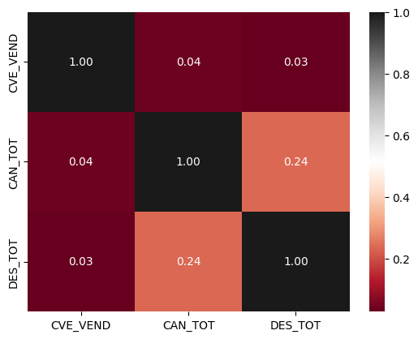

```python
#Mostramos el mapa de calor de los coeficientes de correlación de las variables para cada hoja de cálculo
Heat_Map= sns.heatmap(abs(clientesfact.corr()), cmap = 'RdGy', annot=True, fmt=".2f")
Heat_Map
```

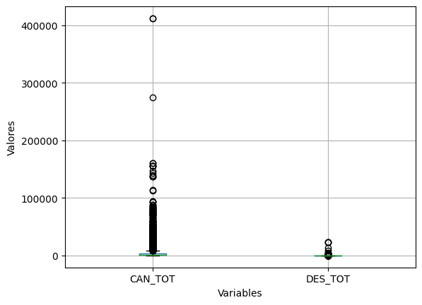

```python
#Mostrar la dispersión de las variables del dataframe
boxplot2 = clientesfact.boxplot(column=['CAN_TOT','DES_TOT'])
boxplot.set_xticklabels(boxplot.get_xticklabels(), rotation=45)
plt.xlabel('Variables')
plt.ylabel('Valores')
plt.show()
```

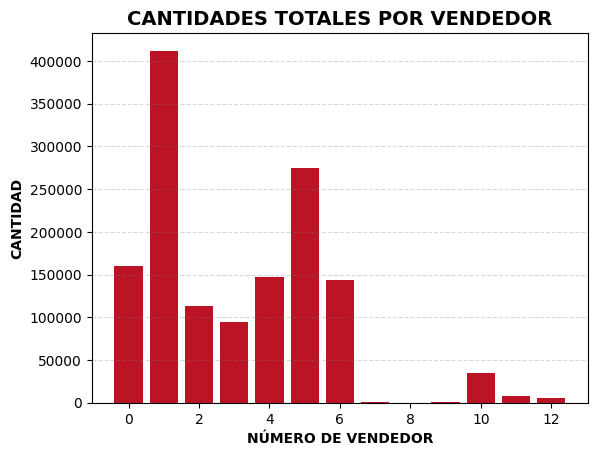

```python
Barras=plt.bar(clientesfact['CVE_VEND'],clientesfact['CAN_TOT'],color='#bc1424')
ax = plt.gca()
ax.set_facecolor('white')
plt.title('CANTIDADES TOTALES POR VENDEDOR',  fontdict = {'fontsize':14, 'fontweight':'bold'})
plt.ylabel('CANTIDAD', fontdict = {'fontsize':10, 'fontweight':'bold'})
plt.xlabel('NÚMERO DE VENDEDOR', fontdict = {'fontsize':10, 'fontweight':'bold'})
plt.grid(axis = 'y', color = 'gray', linestyle = 'dashed', alpha = 0.3)
plt.show()
```

**CLIENTES NOTAS**

- Existen varias columnas numéricas en las cuales se observan porcentajes de correlación diferentes.
- La mayor correlación se observa con las variables "Folio" y "Clave del cliente". mostrando un 17%, siendo así un porcentaje muy pequeño.
- Con un 4%, la correlación menor encontrada se presenta con las variables "Folio" y "Clave del vendedor", presentada en dos dimensiones diferentes del mapa de calor.

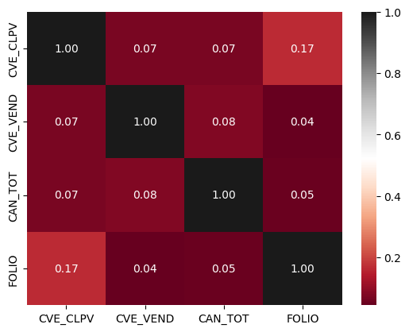

```python
#Mostramos el mapa de calor de los coeficientes de correlación de las variables para cada hoja de cálculo
Heat_Map= sns.heatmap(abs(clientesnot.corr()), cmap = 'RdGy', annot=True, fmt=".2f")
Heat_Map
```

**CLIENTES DEVOLUCIONES**

- Existen varias columnas numéricas en las cuales se observan porcentajes de correlación diferentes.
- La mayor correlación se observa con las variables "Folio" y "Cantidad total". mostrando un 24%, siendo así un porcentaje bajo.
- Con tan sólo un 1%, la correlación menor encontrada se presenta con las variables "Cantidad total" y "Clave del vendedor", presentada en dos dimensiones diferentes del mapa de calor.

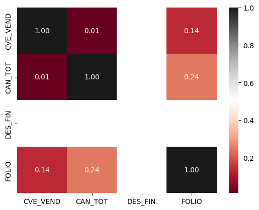

```python
#Mostramos el mapa de calor de los coeficientes de correlación de las variables para cada hoja de cálculo
Heat_Map= sns.heatmap(abs(clientesdev.corr()), cmap = 'RdGy', annot=True, fmt=".2f")
Heat_Map
```

**GASTOS 2020, 2021, 2022, 2023**

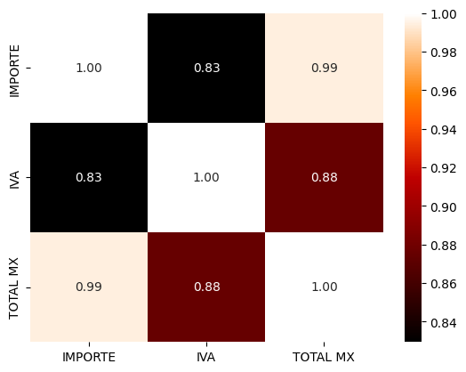

```python
#Mostramos el mapa de calor de los coeficientes de correlación de las variables para cada hoja de cálculo
Heat_Map= sns.heatmap(abs(gastos2020.corr()), cmap = 'gist_heat', annot=True, fmt=".2f")
Heat_Map
```

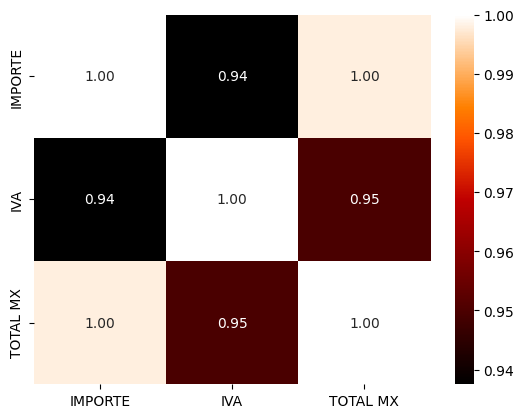

```python
#Mostramos el mapa de calor de los coeficientes de correlación de las variables para cada hoja de cálculo
Heat_Map= sns.heatmap(abs(gastos2021.corr()), cmap = 'gist_heat', annot=True, fmt=".2f")
Heat_Map
```

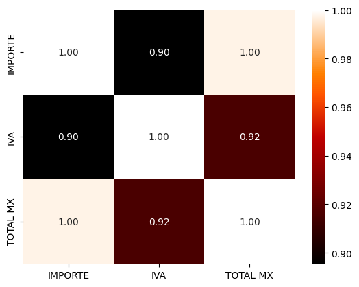

```python
#Mostramos el mapa de calor de los coeficientes de correlación de las variables para cada hoja de cálculo
Heat_Map= sns.heatmap(abs(gastos2022.corr()), cmap = 'gist_heat', annot=True, fmt=".2f")
Heat_Map
```

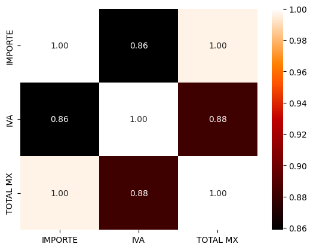

```python
#Mostramos el mapa de calor de los coeficientes de correlación de las variables para cada hoja de cálculo
Heat_Map= sns.heatmap(abs(gastos2023.corr()), cmap = 'gist_heat', annot=True, fmt=".2f")
Heat_Map
```

```python
gastos2020.columns
```

```
Index(['FECHA', 'FOLIO', 'UUID', 'RFC', 'PROVEEDOR', 'TIPO GASTO', 'IMPORTE',
       'IVA', 'TOTAL MX', 'TIPO', 'STATUS'],
      dtype='object')
```

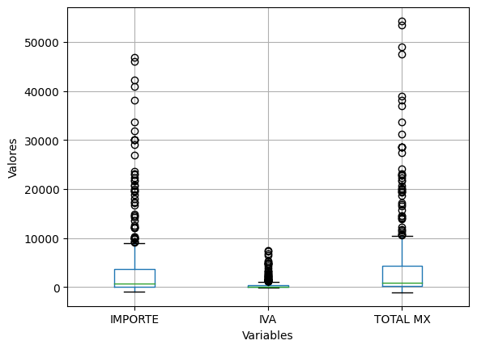

```python
#Mostrar la dispersión de las variables del dataframe
boxplot3 = gastos2023.boxplot(column=['IMPORTE', 'IVA', 'TOTAL MX'])
boxplot.set_xticklabels(boxplot.get_xticklabels(), rotation=45)
plt.xlabel('Variables')
plt.ylabel('Valores')
plt.show()
```

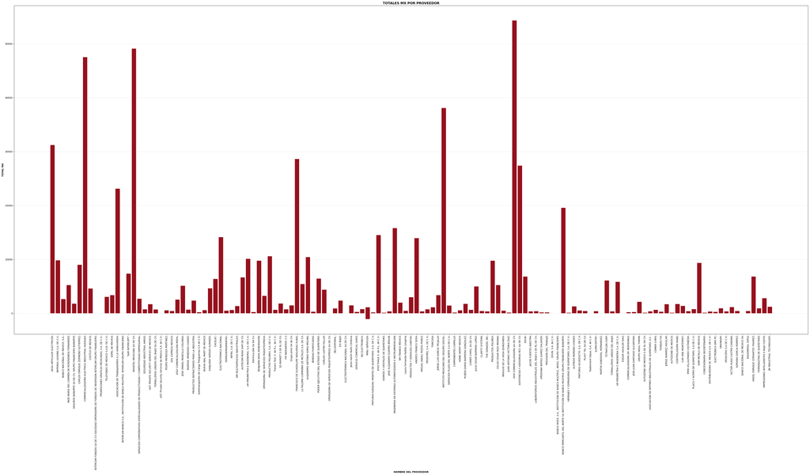

```python
plt.figure(figsize=(60,25))
Barras=plt.bar(gastos2023['PROVEEDOR'],gastos2023['TOTAL MX'],color='#96101d')
ax = plt.gca()
ax.set_facecolor('white')
ax.set_xticklabels(ax.get_xticklabels(), rotation=90)
plt.title('TOTALES MX POR PROVEEDOR',  fontdict = {'fontsize':14, 'fontweight':'bold'})
plt.ylabel('TOTAL MX', fontdict = {'fontsize':10, 'fontweight':'bold'})
plt.xlabel('NOMBRE DEL PROVEEDOR', fontdict = {'fontsize':10, 'fontweight':'bold'})
plt.grid(axis = 'y', color = 'gray', linestyle = 'dashed', alpha = 0.3)
plt.show()
```

```python
%%shell
jupyter nbconvert --to html
```